# Field evaluation of integrated soybean cyst nematode management using spatially informed mixed models - Part 1

Published

October 25, 2025

[GitHub Repository](https://github.com/vcgarnica/SCN_spatial_inference)

This file contains the full R workflow for processing and analyzing raw data, as well as generating figures for the manuscript. The Rmarkdown file can be downloaded from the *Code* drop down menu (top right).

## Soybean cyst nematode

Soybean cyst nematode (SCN), caused by *Heterodera glycines*, is among the most economically damaging pests of soybean in North America. As an obligate, sedentary endoparasite, SCN establishes a syncytium in soybean roots, disrupting nutrient flow, stunting growth, and reducing yield.

Effective SCN management relies on integrated strategies. Host resistance is the most cost-effective tool, with PI 88788 and Peking providing season-long protection when matched to local nematode populations. However, SCN populations display high virulence diversity, and repeated use of the same resistance genes accelerates adaptation. Seed-applied products such as fluopyram can protect soybean yield under SCN pressure, but they generally do not reduce nematode reproduction to the extent achieved by host resistance, and their efficacy remains variable.

This study evaluates integrated SCN management strategies combining resistant cultivars and fluopyram seed treatment on soybean yield and SCN reproduction. We investigate the yield sensitivity of Peking- and PI 88788-derived resistance under pressure from HG Type 1.2–. Critically, we employ advanced spatial modeling to account for field-scale heterogeneity in nematode distribution and soil properties, thereby improving the precision of treatment effect estimates and the reliability of our inferences.

## Objectives

With PI 88788 as the predominant resistance source in Ohio and Peking becoming more available, understanding their performance, both alone and combined with chemical tools, is vital.

Therefore, the objectives of this study are to:

- Evaluate the individual and combined effects of Peking- and PI 88788-derived resistance with fluopyram seed treatment on soybean yield and SCN reproduction in Ohio fields infested with the virulent HG Type 1.2– and 2–.
- Quantify and compare the yield sensitivity (damage coefficients) of these resistance sources to increasing pre-plant SCN pressure
- Employ and compare linear mixed models with spatial covariance structures to control for field heterogeneity, thereby generating more accurate and precise estimates of treatment efficacy

#### Load packages and dataset

```r
required_packages = c(
  "tidyverse",    # Data manipulation and visualization
  "asreml",       # Mixed modeling
  "asremlPlus",   # Model diagnostics
  "kableExtra",   # Table formatting
  "patchwork",    # Plot arrangement
  "TPSbits",      # Tensor spline modeling
  "ggrepel"
)

invisible(lapply(required_packages, library, character.only = TRUE))
```

```
Online License checked out Sat Oct 25 20:06:29 2025
```

```r
asreml.options(gammaPar = TRUE)
theme_set(theme_minimal(base_size = 12))

source("functions.r")

cc = c(
  "#0a0a23",
  "#1e2a5e",
  "#2d4aa7",
  "#3d6bd1",
  "#7ba5f5",
  "#a8c8ff",
  "#d4e6ff",
  "#ffe0d4",
  "#ffb8a8",
  "#ff917b",
  "#ff6b4e",
  "#ff7a33")


tile_data = expand.grid(
  col = c(1.375, 2.125, 2.875, 3.625),
  row = c(1.5, 2.5, 3.5, 4.5, 5.5, 6.5, 7.5, 8.5, 9.5, 10.5,
          11.5, 12.5, 13.5, 14.5, 15.5, 16.5, 17.5, 18.5, 19.5, 20.5,
          21.5, 22.5, 23.5),  # Adjusted row positions
  year = c(2022, 2023)
) %>%
  filter(!((year == 2022) & (row > 19.5)))
```

## Methods

### Experimental conditions and design

Field trials were conducted at the North Central Agricultural Research Station (Sandusky County, Ohio) during the 2022 and 2023 growing seasons, each representing a distinct environment.

A split-plot randomized complete block design with eight replications was used both years (referred to as environments here). Main plots included six Pioneer soybean cultivars with different SCN resistance sources. Subplots received either base seed or fluopyram + base-treated seed. Row and column identifiers were retained for spatial modeling.

### SCN population density metrics

SCN population densities were quantified at three critical time points: pre-planting (initial density, $P_i$), 45 days after planting ($P_{45DAP}$), and at harvest (final density, $P_f$). Population densities are expressed as the number of eggs per 100 cm³ of soil. The nematode reproduction factor was calculated for each plot as $Rf = P_f / P_i$. For statistical analysis, $P_i$ was mean-centered and both $P_i$ and $Rf$ were log-transformed to stabilize variance.

```r
dat = read_csv("pioneers.csv", show_col_types = FALSE)

dat = dat %>%
  mutate(
      trt = factor(as.numeric(interaction(cult, seed_trt, sep = ":"))),
      wp = factor(as.numeric(interaction(cult, block, sep = ":"))),
      across(c(location, block, site, trt, plot, cult, resis, seed_trt), as.factor),
      row_f = factor(row),
      col_f = factor(col),
      SCN_rf = SCN_final/SCN_initial,
      log_centered_initial = log(dat$SCN_initial) - mean(log(dat$SCN_initial), na.rm = TRUE)
    ) %>%
    relocate(trt, .before = cult) %>%
    arrange(site, row, col) %>%
    na.omit() %>%
    droplevels() %>%
    mutate(seed_trt = recode(seed_trt, "ILeVO" = "Fluopyram"),
           seed_trt = recode(seed_trt, "BASE" = "Base"),
           seed_trt = factor(seed_trt, levels = c("Base", "Fluopyram")))

dat %>%
  group_by(year) %>%
  skimr::skim()
```

Data summary

| Name | Piped data |
| --- | --- |
| Number of rows | 176 |
| Number of columns | 20 |
| _______________________ |  |
| Column type frequency: |  |
| factor | 11 |
| numeric | 8 |
| ________________________ |  |
| Group variables | year |

**Variable type: factor**

[output not shown]

**Variable type: numeric**

| skim_variable | year | n_missing | complete_rate | mean | sd | p0 | p25 | p50 | p75 | p100 | hist |
| --- | --- | --- | --- | --- | --- | --- | --- | --- | --- | --- | --- |
| col | 2022 | 0 | 1 | 2.50 | 1.13 | 1.00 | 1.75 | 2.50 | 3.25 | 4.00 | ▇▇▁▇▇ |
| col | 2023 | 0 | 1 | 2.50 | 1.12 | 1.00 | 1.75 | 2.50 | 3.25 | 4.00 | ▇▇▁▇▇ |
| row | 2022 | 0 | 1 | 10.50 | 5.80 | 1.00 | 5.75 | 10.50 | 15.25 | 20.00 | ▇▇▇▇▇ |
| row | 2023 | 0 | 1 | 12.50 | 6.96 | 1.00 | 6.75 | 12.50 | 18.25 | 24.00 | ▇▇▆▇▇ |
| yield_kg_ha | 2022 | 0 | 1 | 5058.88 | 513.64 | 3557.52 | 4833.59 | 5104.27 | 5373.27 | 6086.12 | ▂▂▇▇▃ |
| yield_kg_ha | 2023 | 0 | 1 | 5611.80 | 619.93 | 4041.72 | 5127.81 | 5766.69 | 6104.62 | 6664.48 | ▂▅▅▇▅ |
| SCN_initial | 2022 | 0 | 1 | 15915.00 | 7021.72 | 4840.00 | 10640.00 | 15200.00 | 18920.00 | 36960.00 | ▇▇▅▂▁ |
| SCN_initial | 2023 | 0 | 1 | 6804.17 | 4581.80 | 440.00 | 2940.00 | 6380.00 | 9280.00 | 20680.00 | ▇▇▅▂▁ |
| SCN_45_dap | 2022 | 0 | 1 | 17705.00 | 9867.13 | 4840.00 | 9900.00 | 15480.00 | 22860.00 | 61680.00 | ▇▅▂▁▁ |
| SCN_45_dap | 2023 | 0 | 1 | 5359.17 | 3086.15 | 760.00 | 3000.00 | 4620.00 | 7250.00 | 15360.00 | ▇▇▅▂▁ |
| SCN_final | 2022 | 0 | 1 | 14435.00 | 9252.79 | 2040.00 | 7500.00 | 11720.00 | 19890.00 | 43280.00 | ▇▅▃▂▁ |
| SCN_final | 2023 | 0 | 1 | 5772.08 | 5989.63 | 240.00 | 1710.00 | 3160.00 | 7190.00 | 25320.00 | ▇▂▁▁▁ |
| SCN_rf | 2022 | 0 | 1 | 0.99 | 0.67 | 0.11 | 0.55 | 0.86 | 1.20 | 3.82 | ▇▆▁▁▁ |
| SCN_rf | 2023 | 0 | 1 | 1.22 | 1.48 | 0.04 | 0.36 | 0.71 | 1.48 | 9.79 | ▇▂▁▁▁ |
| log_centered_initial | 2022 | 0 | 1 | 0.57 | 0.45 | -0.53 | 0.26 | 0.62 | 0.84 | 1.51 | ▂▃▇▇▂ |
| log_centered_initial | 2023 | 0 | 1 | -0.47 | 0.85 | -2.92 | -1.03 | -0.25 | 0.12 | 0.93 | ▁▂▅▇▅ |

### Exploratory Analysis

Exploratory analysis was conducted to visualize patterns in the data, assess variability across treatments and cultivars, and identify potential relationships among key variables. Plots were used to examine yield and SCN reproduction responses by resistance source and seed treatment, as well as trends across initial SCN population densities.

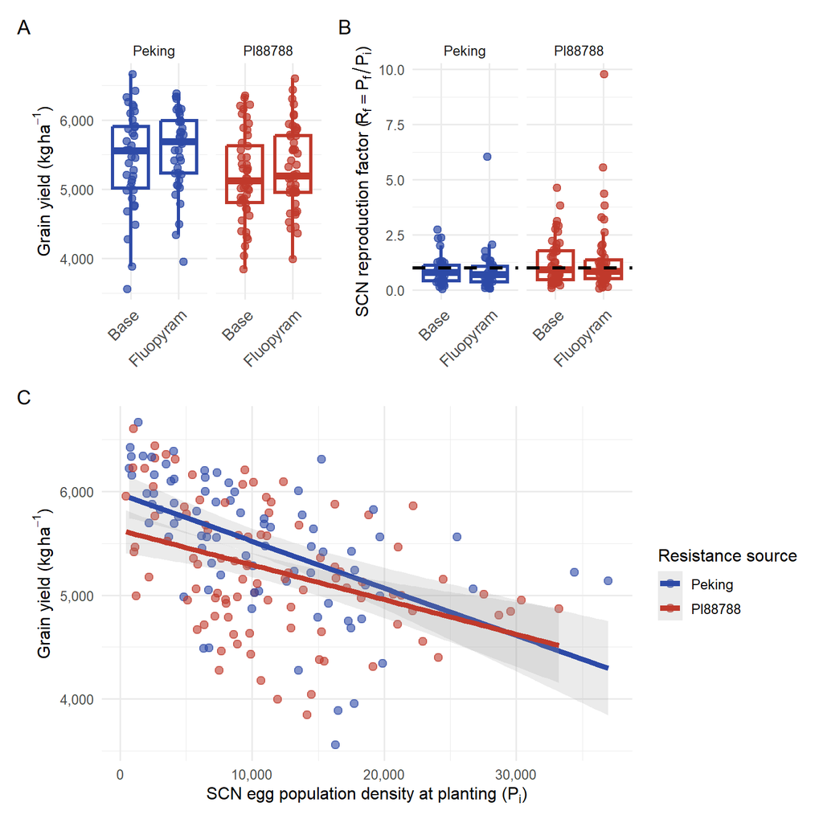

**Figure 1**. Distributions of soybean yield and soybean cyst nematode (SCN) reproduction under different resistance sources and seed treatments. Panels **A** and **B** show boxplots of grain yield and SCN reproduction factor ($R_f$), respectively, stratified by resistance source. Panel **C** illustrates the association between initial SCN density ($P_i$) and yield. Resistance sources are color-coded: blue for Peking-derived and red for PI 88788-derived cultivars.

## Statistical analyses

To evaluate treatment effects both within and across environments, we fitted a suite of linear mixed models using the `ASReml-R` package. Separate model-fitting functions were developed for single-site and multi-site analyses. The fixed effects component included cultivar, seed treatment, and their interaction, with optional covariate adjustment for pre-plant SCN egg density ($P_i$) where appropriate. Random effects were specified to account for the blocking structure (blocks nested within environments) and whole-plot error, in accordance with the split-plot design.

- Baseline: Independent and identically distributed errors
- SCN-adjusted: Baseline + a covariate
- Autoregressive (AR1): Row-wise autoregressive correlation
- AR1 + Nugget: AR1 structure with an additional micro-scale error term
- Trend-Adjusted (TA): AR1 + Nugget with fixed linear row and/or column trends
- Tensor-Product Splines (TPS): A two-dimensional smooth spatial surface using penalized splines

For multi-environment models, heterogeneous residual variances across sites were accommodated using direct-sum formulations, allowing site-specific variance estimates. Model selection was guided by restricted maximum likelihood (REML) and information criteria (adjusted AIC and BIC)

The code below implements the statistical models described in the manuscript, with each model reflecting a distinct spatial variance structure outlined in the mathematical notation section. The `single_site_models()` and `multi_site_models()` functions generate model objects for site-specific and multi-environment analyses, respectively.

```r
single_site_models = function(data, model_type, covariate = NULL) {
  data_name = substitute(data)

  fixed_formula = if (!is.null(covariate)) {
    f = as.formula(paste("yield_kg_ha ~ 1 + cult*seed_trt +", covariate))
    environment(f) = baseenv()
    f
  } else {
    f = as.formula("yield_kg_ha ~ 1 + cult*seed_trt")
    environment(f) = baseenv()
    f
  }

  dat1 = spatial_matrix(data)

  model_expr = switch(model_type,
                       "baseline" = substitute(asreml(
                         fixed = FIXED,
                         random = ~ block + wp,
                         residual = ~ units,
                         data = DAT,
                         na.action = na.method(x = "include", y = "include")
                       ), list(FIXED = fixed_formula, DAT = data_name)),

                       "structured" = substitute(asreml(
                         fixed = FIXED,
                         random = ~ block + wp,
                         residual = ~ id(row_f):id(col_f),
                         data = DAT,
                         na.action = na.method(x = "include", y = "include")
                       ), list(FIXED = fixed_formula, DAT = data_name)),

                       "ar1" = substitute(asreml(
                         fixed = FIXED,
                         random = ~ block + wp,
                         residual = ~ ar1(row_f):id(col_f),
                         data = DAT,
                         na.action = na.method(x = "include", y = "include")
                       ), list(FIXED = fixed_formula, DAT = data_name)),

                       "ar1_nugget" = substitute(asreml(
                         fixed = FIXED,
                         random = ~ block + wp + idv(units),
                         residual = ~ ar1(row_f):id(col_f),
                         data = DAT,
                         na.action = na.method(x = "include", y = "include")
                       ), list(FIXED = fixed_formula, DAT = data_name)),

                       "ta" = substitute(asreml(
                         fixed = update(FIXED, ~ . + lin(row_f) + lin(col_f)),
                         random = ~ block + wp + idv(units),
                         residual = ~ ar1(row_f):id(col_f),
                         data = DAT,
                         na.action = na.method(x = "include", y = "include")
                       ), list(FIXED = fixed_formula, DAT = data_name)),

                      "tps" = {
                         nseg = c(length(unique(data[["col"]])), length(unique(data[["row"]])) / 2)
                         TPXZg = tpsmmb("col", "row", data, stub = "1", nsegments = nseg,
                                         asreml = "grp", eigenvalues = TRUE)

                         substitute(asreml(
                         fixed = update(FIXED, ~ . + TP.CR.2 + TP.CR.3 + TP.CR.4),
                         random = ~ block + wp +
                           grp(TP.C.1_frow) + grp(TP.C.2_frow) + grp(TP.R.1_fcol) + grp(TP.R.2_fcol)+ grp(TP_fcol_frow),
                         group = TPXZg$grp,
                         residual = ~ id(row_f):id(col_f),
                         data = TPXZg$data,
                         na.action = na.method(x = "include", y = "include")),
                         list(FIXED = fixed_formula, TPXZg = TPXZg))
                        }
  )

    eval(model_expr, envir = parent.frame())
}


multi_site_models = function(data, model_type, covariate = NULL) {
  data_name = substitute(data)
  fixed_formula = if (!is.null(covariate)) {
    f = as.formula(paste("yield_kg_ha ~ 1 + site + cult*seed_trt +", covariate))
    environment(f) = baseenv()
    f
  } else {
    f = as.formula("yield_kg_ha ~ 1 + site+ cult*seed_trt")
    environment(f) = baseenv()
    f
  }

  dat1 = spatial_matrix(data)

       model_expr = switch(model_type,
                      "baseline" = substitute(asreml(
                        fixed = FIXED,
                        random = ~ at(site):block +  at(site):wp,
                        residual = ~dsum(~units | site),
                        maxit = 100,
                        data = DAT,
                        na.action = na.method(x = "include", y = "include")
                      ), list(FIXED = fixed_formula, DAT = data_name)),

                      "structured" = substitute(asreml(
                        fixed = FIXED,
                        random = ~ at(site):block +  at(site):wp,
                        residual = ~dsum(~id(row):id(col) | site),
                        maxit = 100,
                        data = DAT,
                        na.action = na.method(x = "include", y = "include")
                      ), list(FIXED = fixed_formula, DAT = data_name)),

                      "ar1" = substitute(asreml(
                        fixed = FIXED,
                        random = ~ at(site):block +  at(site):wp,
                        residual = ~dsum(~ar1(row_f):id(col_f) | site),
                        data = DAT,
                        na.action = na.method(x = "include", y = "include")
                      ), list(FIXED = fixed_formula, DAT = data_name)),

                      "ar1_nugget" = substitute(asreml(
                        fixed = FIXED,
                        random = ~ at(site):block + at(site):wp + at(site):idv(units),
                        residual = ~dsum(~ar1(row_f):id(col_f) | site),
                        data = DAT,
                        na.action = na.method(x = "include", y = "include")
                      ), list(FIXED = fixed_formula, DAT = data_name)),

                      "ta" = substitute(asreml(
                        fixed = update(FIXED, ~ . + at(site):lin(row_f) + at(site):lin(col_f)),
                        random = ~ at(site):block + at(site):wp + at(site):idv(units),
                        residual = ~dsum(~ar1(row_f):id(col_f) | site),
                        data = DAT,
                        na.action = na.method(x = "include", y = "include")
                      ), list(FIXED = fixed_formula, DAT = data_name)),

                      "tps" = substitute(asreml(
                        fixed = update(FIXED, ~ . + at(site):TP.CR.2 + at(site):TP.CR.3 + at(site):TP.CR.4),
                        random = ~ at(site):block + at(site):wp +
                          at(site):grp(TP.C.1_frow) + at(site):grp(TP.C.2_frow) + at(site):grp(TP.R.1_fcol) + at(site):grp(TP.R.2_fcol)+ at(site):grp(TP_fcol_frow),
                        group = DAT1_group,
                        residual =~dsum(~id(row_f):id(col_f)|site),
                        data = DAT1,
                        na.action = na.method(x = "include", y = "include")
                      ), list(FIXED = fixed_formula, DAT1 = dat1$data, DAT1_group = dat1$grp)),
                    )

  eval(model_expr, envir = parent.frame())
}
```

# 1 2022 Single-site Analysis

This section describes the modeling workflow for the 2022 soybean field trial.

### 1.0.1 Baseline Model

This model serves as a reference, assuming independent residuals and no spatial structure.

```r
baseline = single_site_models(trial_2022, "baseline")
```

```r
wald(baseline,  trace=FALSE)
```

```
Wald tests for fixed effects.
Response: yield_kg_ha
Terms added sequentially; adjusted for those above.

              Df Sum of Sq Wald statistic Pr(Chisq)
(Intercept)    1  72741337        1370.36 < 2.2e-16 ***
cult           4    720063          13.57 0.0088205 **
seed_trt       1    795177          14.98 0.0001086 ***
cult:seed_trt  4     92291           1.74 0.7836858
residual (MS)        53082
---
Signif. codes:  0 '***' 0.001 '**' 0.01 '*' 0.05 '.' 0.1 ' ' 1
```

### 1.0.2 Baseline Structured Model

This is the same model as above, with the difference it accounts for physical plot layout in residuals. Residuals are independent row and column effects. This allows us with options to model correlation along rows or columns (next model).

```r
structured = single_site_models(trial_2022, "structured")
```

```r
wald(structured,  trace=FALSE)
```

```
Wald tests for fixed effects.
Response: yield_kg_ha
Terms added sequentially; adjusted for those above.

              Df Sum of Sq Wald statistic Pr(Chisq)
(Intercept)    1  72741337        1370.36 < 2.2e-16 ***
cult           4    720063          13.57 0.0088205 **
seed_trt       1    795177          14.98 0.0001086 ***
cult:seed_trt  4     92291           1.74 0.7836858
residual (MS)        53082
---
Signif. codes:  0 '***' 0.001 '**' 0.01 '*' 0.05 '.' 0.1 ' ' 1
```

Exact $P$ values and variance components are reported from the baseline model, now accounting for row and column IDs.

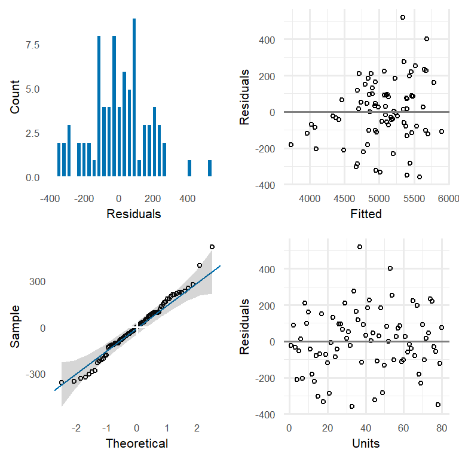

```r
plot(structured)
```

The residual diagnostic plot shows spatial trends after adjusting for fixed and random effects, while the variogram assesses the magnitude and direction of spatial correlation. Residuals should ideally appear random, without row- or column-wise patterns, indicating that the spatial structure adequately captures field heterogeneity. Some residual spatial structure remains, but the model provides a reasonable adjustment. Model fit may be further assessed using AIC and BIC.

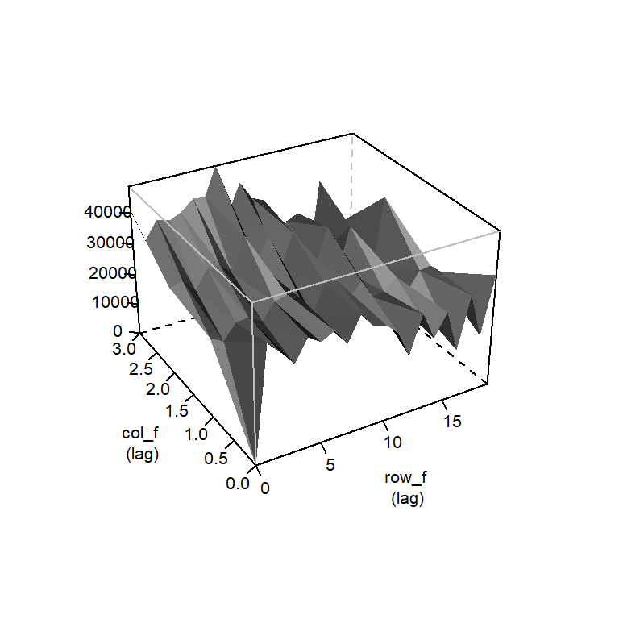

```r
plot(asreml::varioGram(structured))
```

Using a separable spatial structure (e.g., `ar1(row):id(col)`) allows two-dimensional diagnostics. In a well-fitted model, the directional variogram should be relatively flat. Here, a slight downward trend from row 10 to 20 suggests residual spatial dependence that could be addressed with additional modeling.

### 1.0.3 SCN-adjusted

This model incorporates plot-level SCN variability by including the log-transformed initial SCN egg count as a covariate `"resis:log_centered_initial"`. Separate coefficients are estimated for each resistance source (Peking and PI 88788), quantifying how yield responds to increasing SCN pressure and whether cultivars differ in yield loss under higher initial infestation.

```r
scn_covariate = single_site_models(trial_2022, "structured", "resis:log_centered_initial")
```

```r
wald(scn_covariate,  trace=FALSE)
```

```
Wald tests for fixed effects.
Response: yield_kg_ha
Terms added sequentially; adjusted for those above.

                           Df Sum of Sq Wald statistic Pr(Chisq)
(Intercept)                 1  79502628        1420.35 < 2.2e-16 ***
cult                        4    774125          13.83 0.0078575 **
seed_trt                    1    795177          14.21 0.0001638 ***
cult:seed_trt               4     92291           1.65 0.7999920
resis:log_centered_initial  2     55690           0.99 0.6080677
residual (MS)                     55974
---
Signif. codes:  0 '***' 0.001 '**' 0.01 '*' 0.05 '.' 0.1 ' ' 1
```

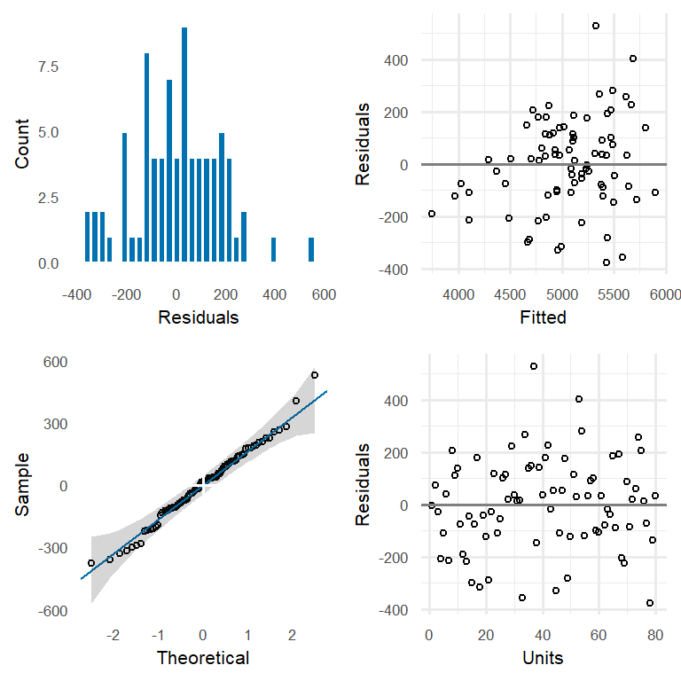

```r
plot(scn_covariate)
```

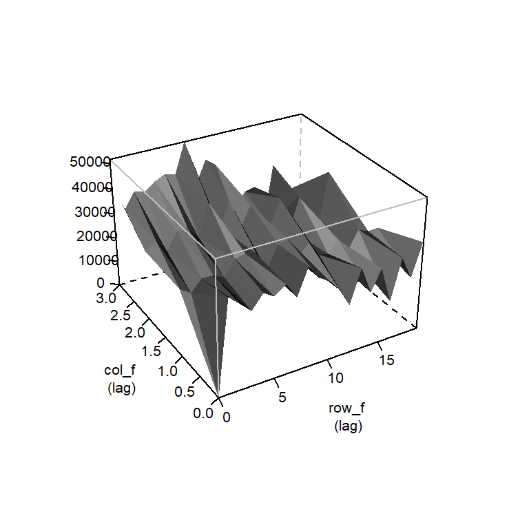

```r
plot(asreml::varioGram(scn_covariate))
```

### 1.0.4 Row-wise first-order autoregressive (AR1) model

This model captures spatial correlation along rows, assuming correlation decays exponentially with distance.

```r
ar1 = single_site_models(trial_2022, "ar1", "resis:log_centered_initial")
ar1 = update.asreml(ar1)
```

```r
wald(ar1,  trace=FALSE)
```

```
Wald tests for fixed effects.
Response: yield_kg_ha
Terms added sequentially; adjusted for those above.

                           Df Sum of Sq Wald statistic Pr(Chisq)
(Intercept)                 1 225097443        1517.05 < 2.2e-16 ***
cult                        4   3706612          24.98 5.076e-05 ***
seed_trt                    1   2208921          14.89 0.0001141 ***
cult:seed_trt               4    143964           0.97 0.9142740
resis:log_centered_initial  2     82948           0.56 0.7561500
residual (MS)                    148379
---
Signif. codes:  0 '***' 0.001 '**' 0.01 '*' 0.05 '.' 0.1 ' ' 1
```

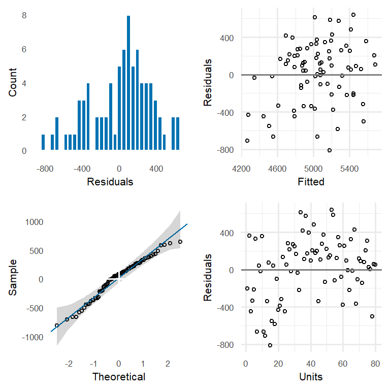

```r
plot(ar1)
```

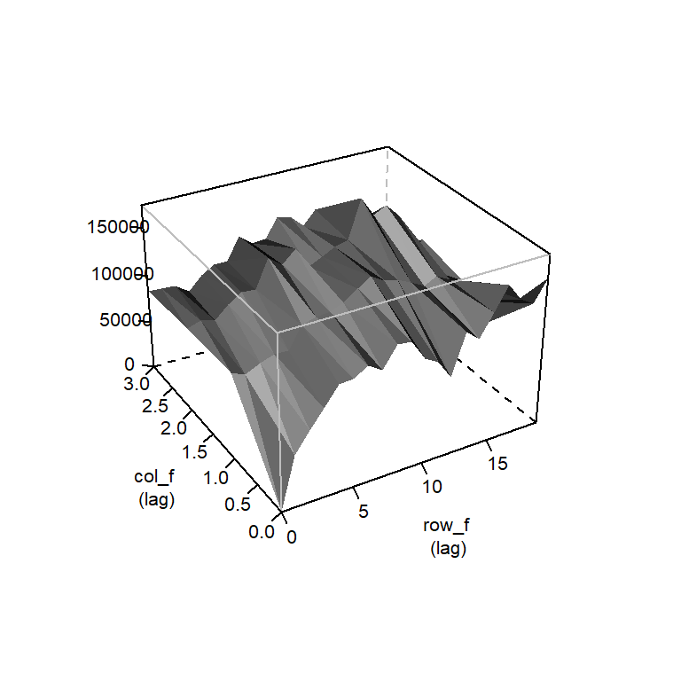

```r
plot(asreml::varioGram(ar1))
```

### 1.0.5 AR1 with independent error term (AR1 + Nugget) model

An independent error term (nugget) is added to capture plot-level measurement variability or micro-scale heterogeneity.

```r
ar1_nugget = single_site_models(trial_2022, "ar1_nugget", "resis:log_centered_initial")
ar1_nugget = update.asreml(ar1_nugget)
```

```r
wald(ar1_nugget,  trace=FALSE)
```

```
Wald tests for fixed effects.
Response: yield_kg_ha
Terms added sequentially; adjusted for those above.

                           Df Sum of Sq Wald statistic Pr(Chisq)
(Intercept)                 1 187604633        1092.88 < 2.2e-16 ***
cult                        4   4054810          23.62 9.513e-05 ***
seed_trt                    1   2254229          13.13 0.0002903 ***
cult:seed_trt               4    178166           1.04 0.9039956
resis:log_centered_initial  2     99327           0.58 0.7487776
residual (MS)                    171660
---
Signif. codes:  0 '***' 0.001 '**' 0.01 '*' 0.05 '.' 0.1 ' ' 1
```

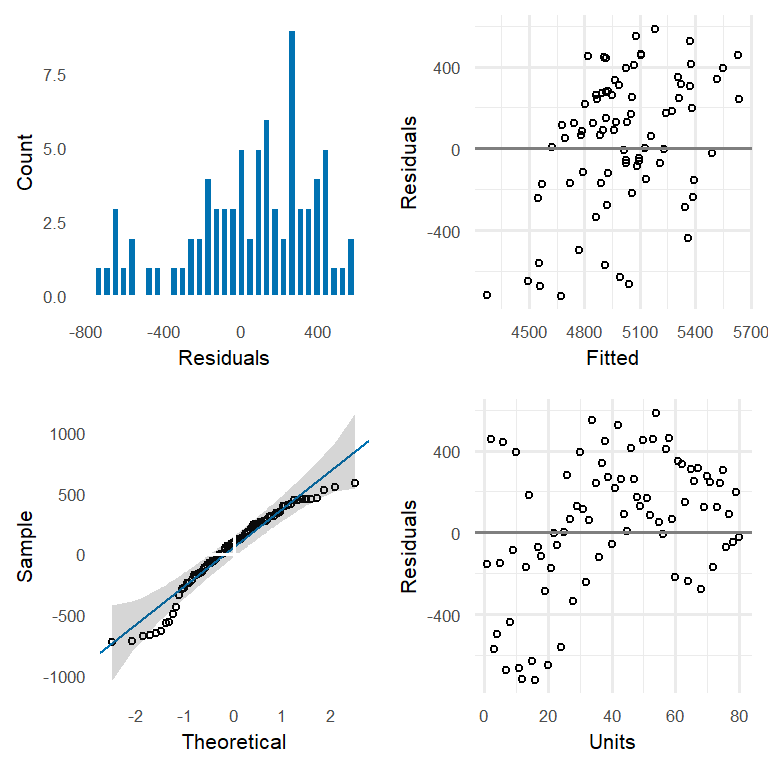

```r
plot(ar1_nugget)
```

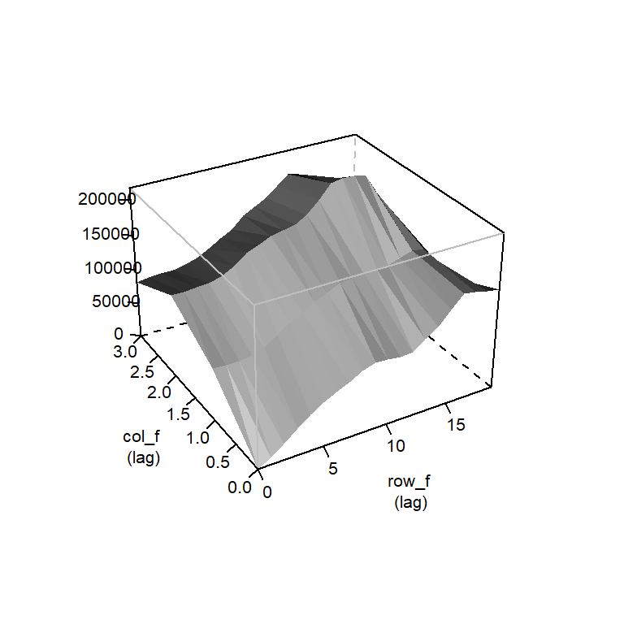

```r
plot(asreml::varioGram(ar1_nugget))
```

### 1.0.6 Trend-adjusted (TA) spatial model

In this model, deterministic linear trends along rows and columns are included to account for field-scale spatial gradients.

```r
ta = single_site_models(trial_2022, "ta", "resis:log_centered_initial")
ta = update.asreml(ta)
```

```r
wald(ta,  trace=FALSE)
```

```
Wald tests for fixed effects.
Response: yield_kg_ha
Terms added sequentially; adjusted for those above.

                           Df Sum of Sq Wald statistic Pr(Chisq)
(Intercept)                 1 223643837        1843.62 < 2.2e-16 ***
cult                        4   2783709          22.95 0.0001297 ***
seed_trt                    1   1577913          13.01 0.0003102 ***
lin(row_f)                  1    339839           2.80 0.0941776 .
lin(col_f)                  1    346309           2.85 0.0911008 .
cult:seed_trt               4    109724           0.90 0.9239121
resis:log_centered_initial  2     48218           0.40 0.8197593
residual (MS)                    121307
---
Signif. codes:  0 '***' 0.001 '**' 0.01 '*' 0.05 '.' 0.1 ' ' 1
```

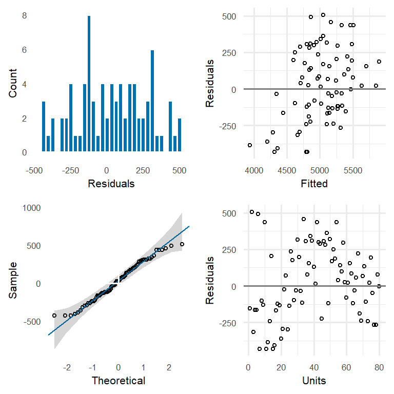

```r
plot(ta)
```

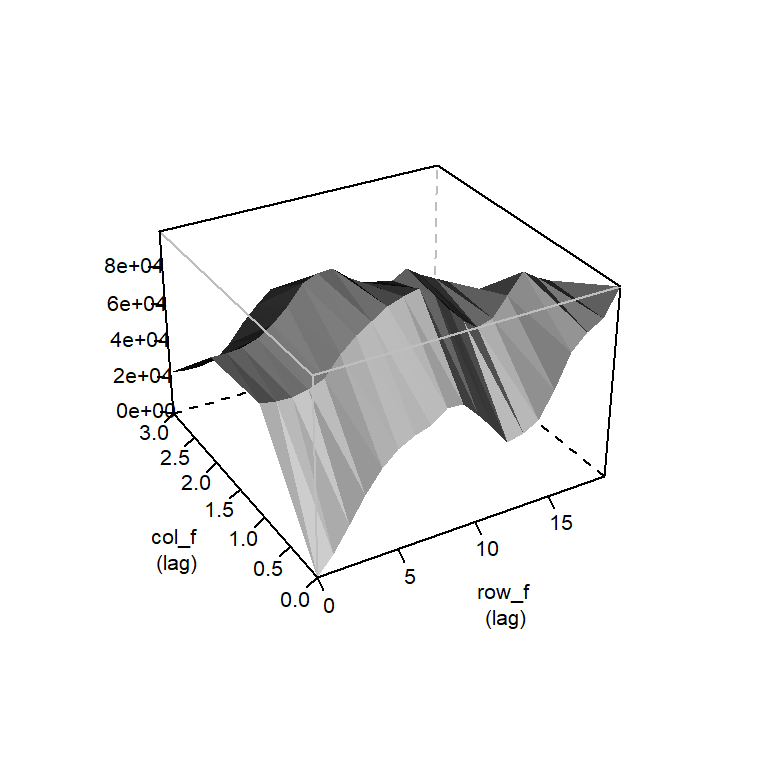

```r
plot(asreml::varioGram(ta))
```

### 1.0.7 Tensor Product P-Spline Model (TPS)

Unlike previous models, this approach captures spatial variation using a flexible two-dimensional surface fit with penalized P-splines over rows and columns. This allows for smooth modeling of field-level trends without assuming a specific spatial covariance structure.

```r
tps =  single_site_models(trial_2022, "tps", "resis:log_centered_initial")
tps = update.asreml(tps)
```

```r
wald(tps, trace=FALSE)
```

```
Wald tests for fixed effects.
Response: yield_kg_ha
Terms added sequentially; adjusted for those above.

                           Df Sum of Sq Wald statistic Pr(Chisq)
(Intercept)                 1 196005782         3959.2 < 2.2e-16 ***
cult                        4   1168420           23.6 9.599e-05 ***
seed_trt                    1    782695           15.8 7.003e-05 ***
TP.CR.2                     1    471619            9.5  0.002025 **
TP.CR.3                     1    147481            3.0  0.084349 .
TP.CR.4                     1    107189            2.2  0.141170
cult:seed_trt               4     64867            1.3  0.859629
resis:log_centered_initial  2      5966            0.1  0.941528
residual (MS)                     49506
---
Signif. codes:  0 '***' 0.001 '**' 0.01 '*' 0.05 '.' 0.1 ' ' 1
```

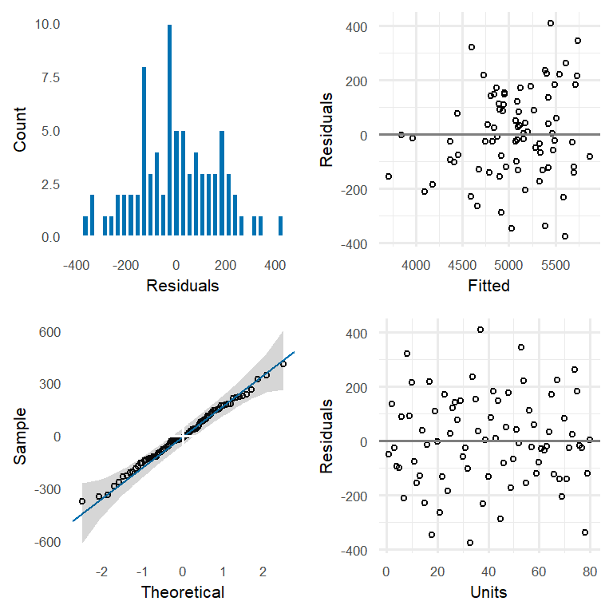

```r
plot(tps)
```

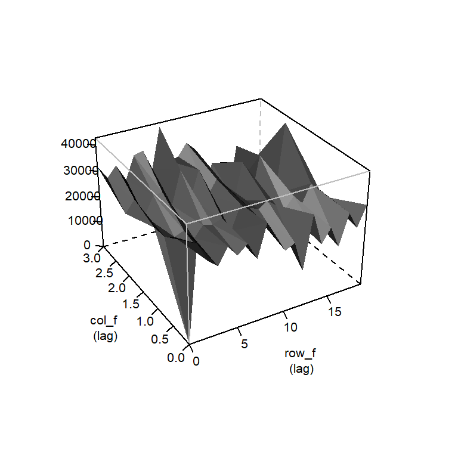

```r
plot(asreml::varioGram(tps))
```

## 1.1 Model Comparisons

Model fit statistics are extracted for all candidate models using REML-based information criteria.

| model | loglik | p | q | b | AIC | BIC | logdet |
| --- | --- | --- | --- | --- | --- | --- | --- |
| baseline | -503.4 | 10 | 3 | 0 | 1,032.7 | 1,063.7 | 96.3 |
| scn_covariate | -503.0 | 12 | 3 | 0 | 1,035.9 | 1,071.7 | 116.3 |
| ar1 | -500.1 | 12 | 3 | 1 | 1,030.2 | 1,065.9 | 114.2 |
| ar1_nugget | -499.1 | 12 | 5 | 0 | 1,032.2 | 1,072.7 | 114.4 |
| ta | -496.7 | 14 | 5 | 0 | 1,031.5 | 1,076.8 | 128.8 |
| tps | -492.7 | 15 | 4 | 4 | 1,023.3 | 1,068.6 | 154.5 |

The 2022 model fit improves with spatial complexity. TPS captures spatial heterogeneity most effectively, enhancing model accuracy over spatial and non-spatial approaches, based on AIC but not on BIC.

## 1.2 Seed Treatment Effects

This section extracts and summarizes the estimated contrasts for seed treatment effects from all models fitted to 2022 data. The contrasts quantify differences in yield between seed treatments, with confidence intervals and standard errors.

| Model | Contrast | Reference | predicted.value | standard.error | lower.Confidence.limit | upper.Confidence.limit |
| --- | --- | --- | --- | --- | --- | --- |
| baseline | Fluopyram vs Base | 4,959.2 | 199.4 | 51.5 | 94.8 | 304.0 |
| scn_covariate | Fluopyram vs Base | 4,966.3 | 193.0 | 54.4 | 82.4 | 303.6 |
| ar1 | Fluopyram vs Base | 4,954.3 | 185.1 | 51.5 | 81.3 | 289.0 |
| ar1_nugget | Fluopyram vs Base | 4,930.4 | 185.5 | 54.4 | 74.6 | 296.4 |
| ta | Fluopyram vs Base | 4,944.4 | 183.3 | 54.8 | 71.5 | 295.1 |
| tps | Fluopyram vs Base | 4,932.6 | 195.1 | 52.3 | 89.0 | 301.2 |

Only the estimated $\overline{D}$ (see manuscript for reference) for the TPS model was reported in the Results section but here and in the supplementary materials, we include the estimates for all models for comparison. The baseline model, representing the traditional split-plot design model, has $\overline{D} = 199.4$, while the TPS model has $\overline{D} = 195.1$. The precision (standard error) are relatively consistent across all models. As a side note, this comparison is at the sub-plot level.

## 1.3 Cultivar and Interaction Comparisons

Similarly, cultivar effects are compared across models, focusing on differences in yield among soybean cultivars with different resistance sources.

| Model | Contrast | Reference | predicted.value | standard.error | lower.Confidence.limit | upper.Confidence.limit |
| --- | --- | --- | --- | --- | --- | --- |
| baseline | Peking vs PI88788 | 5,068.1 | -23.1 | 97.7 | -223.2 | 177.0 |
| scn_covariate | Peking vs PI88788 | 5,087.2 | -60.9 | 146.3 | -361.2 | 239.4 |
| ar1 | Peking vs PI88788 | 5,051.2 | -10.6 | 124.3 | -259.1 | 237.8 |
| ar1_nugget | Peking vs PI88788 | 5,020.1 | 7.5 | 118.7 | -241.5 | 256.6 |
| ta | Peking vs PI88788 | 5,032.4 | 9.2 | 120.6 | -243.9 | 262.2 |
| tps | Peking vs PI88788 | 5,016.4 | 34.3 | 119.2 | -212.5 | 281.2 |
| baseline | Peking + Base vs PI88788 + Fluopyram | 5,149.1 | -231.9 | 110.9 | -457.1 | -6.7 |
| scn_covariate | Peking + Base vs PI88788 + Fluopyram | 5,159.9 | -265.8 | 147.7 | -566.1 | 34.5 |
| ar1 | Peking + Base vs PI88788 + Fluopyram | 5,118.6 | -208.3 | 126.3 | -462.6 | 45.9 |
| ar1_nugget | Peking + Base vs PI88788 + Fluopyram | 5,088.1 | -190.4 | 122.9 | -440.3 | 59.5 |
| ta | Peking + Base vs PI88788 + Fluopyram | 5,101.7 | -185.3 | 124.6 | -438.8 | 68.2 |
| tps | Peking + Base vs PI88788 + Fluopyram | 5,089.8 | -172.9 | 122.2 | -420.5 | 74.7 |

We stick with the TPS model because it had the lowest ajusted AIC but discuss the results of other models for comparison. The contrasts comparing Peking versus PI88788 resistance sources show wide variation in estimates across models, ranging from -60.9 to 34.3, with all confidence intervals overlapping zero. This indicates that Peking did not improve yield, relative to PI88788, in 2022.

In contrast, the resistance × seed treatment interaction (Peking + Base vs. PI 88788 + Fluopyram) consistently shows negative estimates. For this site, the baseline model suggests marginal statistical significance. Spatial models yield a wide confidence intervals that include zero, reflecting increased uncertainty. For reference using the TPS model, Base + Peking yields ~173 kg ha⁻¹ less than Fluopyram + PI 88788, but it is not statistically significant.

## 1.4 Variance Components

Variance components for each model are extracted to highlight sources of variation (e.g., block, residual, spatial effects). This provides insight into how much variation each model attributes to different experimental factors.

| Component | baseline | scn_covariate | ar1 | ar1_nugget | ta | tps |
| --- | --- | --- | --- | --- | --- | --- |
| block | 131445.2 (79922.2) | 126394.7 (77637.2) | 87074.3 (72102.3) | 39099.7 (61291.3) | 27398.3 (51648.3) | 0.08 (NA) |
| wp | 65091.5 (25301.4) | 61904.6 (25535.9) | 0.02 (NA) | 3488.4 (20571.3) | 5565.7 (22269.4) | 23419.9 (17783.4) |
| units!R | 53081.9 (12690.6) | NA | NA | NA | NA | NA |
| row_f:col_f!R | NA | 55973.8 (13684.5) | 148378.9 (46584.3) | 171660.0 (100832.9) | 121307.2 (75635.8) | 49506.1 (12990.6) |
| row_f:col_f!row_f!cor | NA | NA | 0.57 (0.13) | 0.86 (0.12) | 0.80 (0.18) | NA |
| units!units | NA | NA | NA | 37757.8 (18991.3) | 37761.2 (21763.1) | NA |
| grp(TP.R.1_fcol) | NA | NA | NA | NA | NA | 2259300.8 (NA) |
| grp(TP.R.2_fcol) | NA | NA | NA | NA | NA | 839203.7 (1180109.2) |
| grp(TP.C.1_frow) | NA | NA | NA | NA | NA | 368804.5 (295623.5) |
| grp(TP.C.2_frow) | NA | NA | NA | NA | NA | 417443.6 (465926.6) |
| grp(TP_fcol_frow) | NA | NA | NA | NA | NA | 0.01 (NA) |

## 1.5 Coeficient of Damage

| Model | Resistance | Estimate | StdError | PercentEffect |
| --- | --- | --- | --- | --- |
| scn_covariate | Peking_initial | -69.9 | 135.1 | -1.4 |
| scn_covariate | PI88788_initial | -131.2 | 148.3 | -2.5 |
| ar1 | Peking_initial | -25.3 | 123.8 | -0.5 |
| ar1 | PI88788_initial | -99.8 | 135.3 | -2.0 |
| ar1_nugget | Peking_initial | -16.2 | 123.4 | -0.3 |
| ar1_nugget | PI88788_initial | -98.9 | 130.2 | -1.9 |
| ta | Peking_initial | 8.5 | 125.8 | 0.2 |
| ta | PI88788_initial | -80.6 | 131.4 | -1.5 |
| tps | Peking_initial | -19.2 | 124.7 | -0.4 |
| tps | PI88788_initial | -43.5 | 132.1 | -0.8 |

# 2 2023 Single-site Analysis

We do not discuss these results in detail, but the interpretation follows the same rationale above.

### 2.0.1 Baseline Model

```r
baseline = single_site_models(trial_2023, "baseline")
```

```r
wald(baseline,  trace=FALSE)
```

```
Wald tests for fixed effects.
Response: yield_kg_ha
Terms added sequentially; adjusted for those above.

              Df Sum of Sq Wald statistic Pr(Chisq)
(Intercept)    1 141244497        1174.77 < 2.2e-16 ***
cult           5   8194690          68.16 2.477e-13 ***
seed_trt       1    119558           0.99    0.3187
cult:seed_trt  5    577136           4.80    0.4407
residual (MS)       120232
---
Signif. codes:  0 '***' 0.001 '**' 0.01 '*' 0.05 '.' 0.1 ' ' 1
```

```r
structured = single_site_models(trial_2023, "structured")
```

```r
wald(structured,  trace=FALSE)
```

```
Wald tests for fixed effects.
Response: yield_kg_ha
Terms added sequentially; adjusted for those above.

              Df Sum of Sq Wald statistic Pr(Chisq)
(Intercept)    1 141244497        1174.77 < 2.2e-16 ***
cult           5   8194690          68.16 2.477e-13 ***
seed_trt       1    119558           0.99    0.3187
cult:seed_trt  5    577136           4.80    0.4407
residual (MS)       120232
---
Signif. codes:  0 '***' 0.001 '**' 0.01 '*' 0.05 '.' 0.1 ' ' 1
```

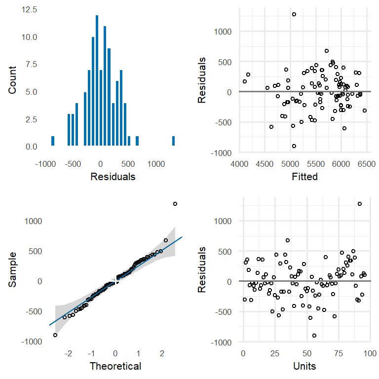

```r
plot(structured)
```

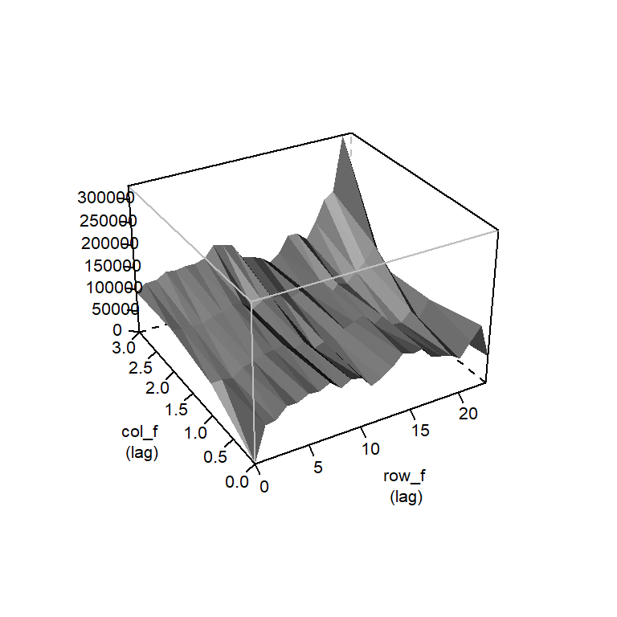

```r
plot(asreml::varioGram(structured))
```

### 2.0.2 SCN-adjusted

```r
scn_covariate = single_site_models(trial_2023, "structured", "resis:log_centered_initial")
```

```r
wald(scn_covariate,  trace=FALSE)
```

```
Wald tests for fixed effects.
Response: yield_kg_ha
Terms added sequentially; adjusted for those above.

                           Df Sum of Sq Wald statistic Pr(Chisq)
(Intercept)                 1 165749067        1755.77 < 2.2e-16 ***
cult                        5   7286684          77.19 3.220e-15 ***
seed_trt                    1    118684           1.26    0.2622
cult:seed_trt               5    576981           6.11    0.2955
resis:log_centered_initial  2   2064222          21.87 1.786e-05 ***
residual (MS)                     94402
---
Signif. codes:  0 '***' 0.001 '**' 0.01 '*' 0.05 '.' 0.1 ' ' 1
```

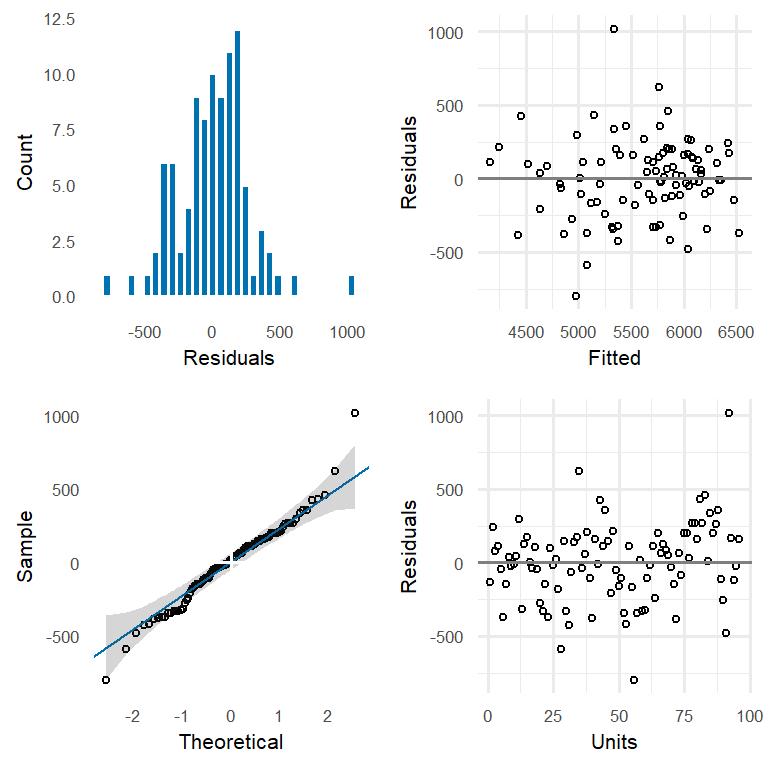

```r
plot(scn_covariate)
```

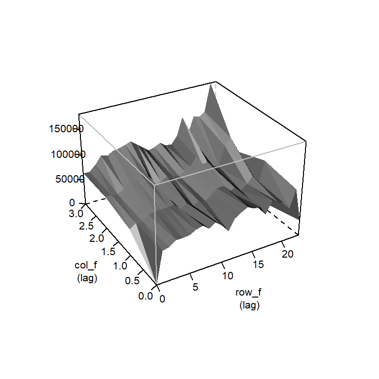

```r
plot(asreml::varioGram(scn_covariate))
```

### 2.0.3 Row-wise first-order autoregressive (AR1) model

```r
ar1 = single_site_models(trial_2023, "ar1", "resis:log_centered_initial")
ar1 = update.asreml(ar1)
```

```r
wald(ar1,  trace=FALSE)
```

```
Wald tests for fixed effects.
Response: yield_kg_ha
Terms added sequentially; adjusted for those above.

                           Df Sum of Sq Wald statistic Pr(Chisq)
(Intercept)                 1 222165834        1930.13 < 2.2e-16 ***
cult                        5   5856168          50.88 9.165e-10 ***
seed_trt                    1    287514           2.50   0.11400
cult:seed_trt               5   1570873          13.65   0.01801 *
resis:log_centered_initial  2   2248180          19.53 5.738e-05 ***
residual (MS)                    115104
---
Signif. codes:  0 '***' 0.001 '**' 0.01 '*' 0.05 '.' 0.1 ' ' 1
```

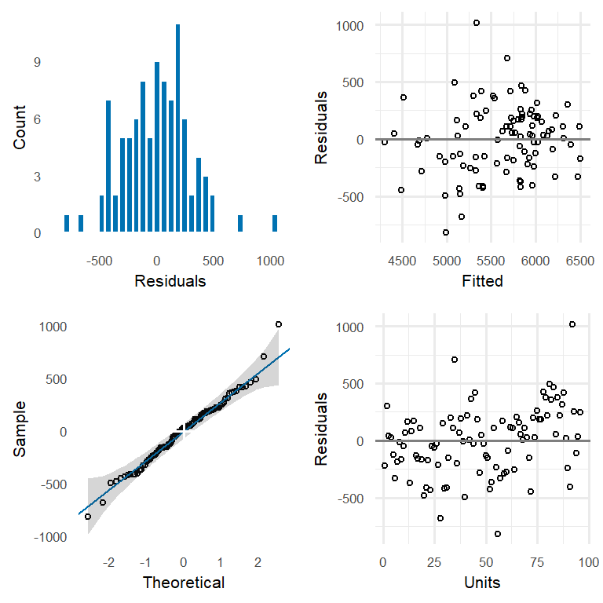

```r
plot(ar1)
```

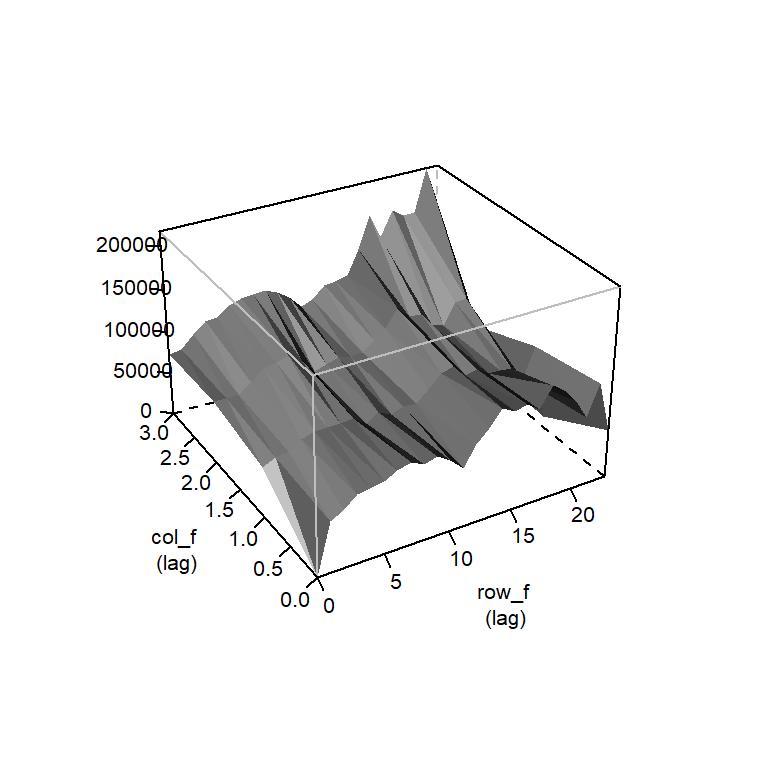

```r
plot(asreml::varioGram(ar1))
```

### 2.0.4 AR1 with independent error term (AR1 + Nugget) model

```r
ar1_nugget = single_site_models(trial_2023, "ar1_nugget", "resis:log_centered_initial")
ar1_nugget = update.asreml(ar1_nugget)
```

```r
wald(ar1_nugget,  trace=FALSE)
```

```
Wald tests for fixed effects.
Response: yield_kg_ha
Terms added sequentially; adjusted for those above.

                           Df Sum of Sq Wald statistic Pr(Chisq)
(Intercept)                 1 201565003        1132.12 < 2.2e-16 ***
cult                        5  13085069          73.49 1.921e-14 ***
seed_trt                    1    494453           2.78   0.09562 .
cult:seed_trt               5   2139854          12.02   0.03453 *
resis:log_centered_initial  2   3703745          20.80 3.039e-05 ***
residual (MS)                    178042
---
Signif. codes:  0 '***' 0.001 '**' 0.01 '*' 0.05 '.' 0.1 ' ' 1
```

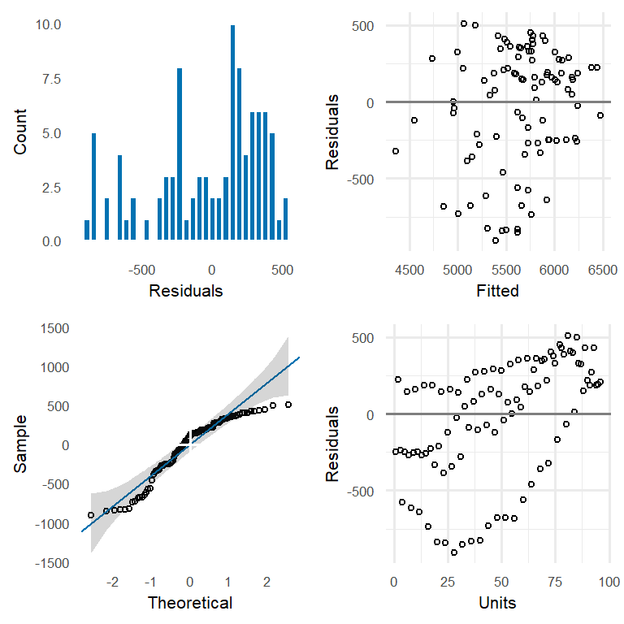

```r
plot(ar1_nugget)
```

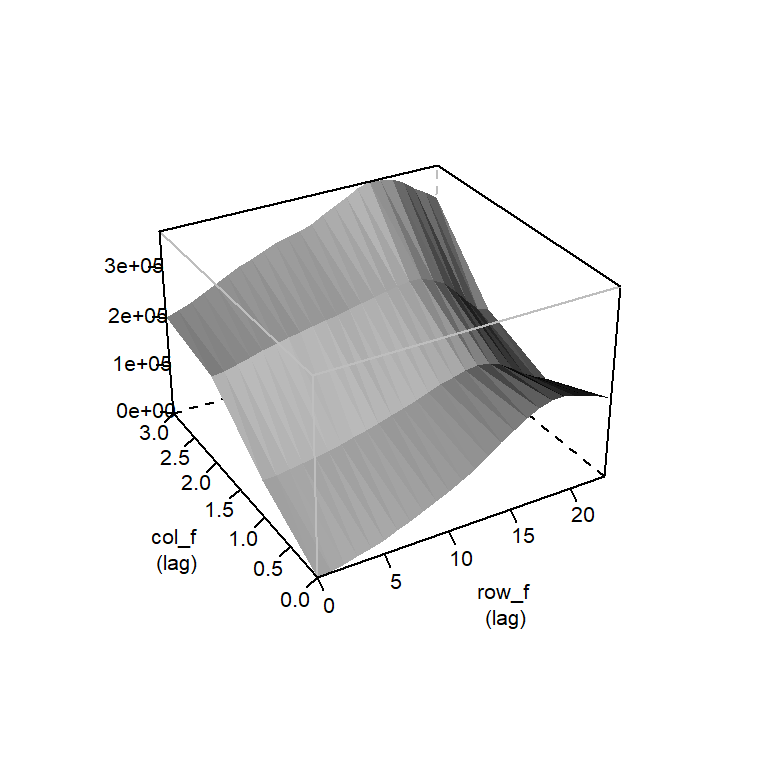

```r
plot(asreml::varioGram(ar1_nugget))
```

### 2.0.5 Trend-adjusted (TA) spatial model

```r
ta = single_site_models(trial_2023, "ta", "resis:log_centered_initial")
ta = update.asreml(ta)
```

```r
wald(ta,  trace=FALSE)
```

```
Wald tests for fixed effects.
Response: yield_kg_ha
Terms added sequentially; adjusted for those above.

                           Df Sum of Sq Wald statistic Pr(Chisq)
(Intercept)                 1 222743916         3288.6 < 2.2e-16 ***
cult                        5   5507678           81.3 4.441e-16 ***
seed_trt                    1    172158            2.5  0.110869
lin(row_f)                  1    166288            2.5  0.117143
lin(col_f)                  1    585850            8.6  0.003271 **
cult:seed_trt               5    724669           10.7  0.057682 .
resis:log_centered_initial  2   1951956           28.8 5.521e-07 ***
residual (MS)                     67731
---
Signif. codes:  0 '***' 0.001 '**' 0.01 '*' 0.05 '.' 0.1 ' ' 1
```

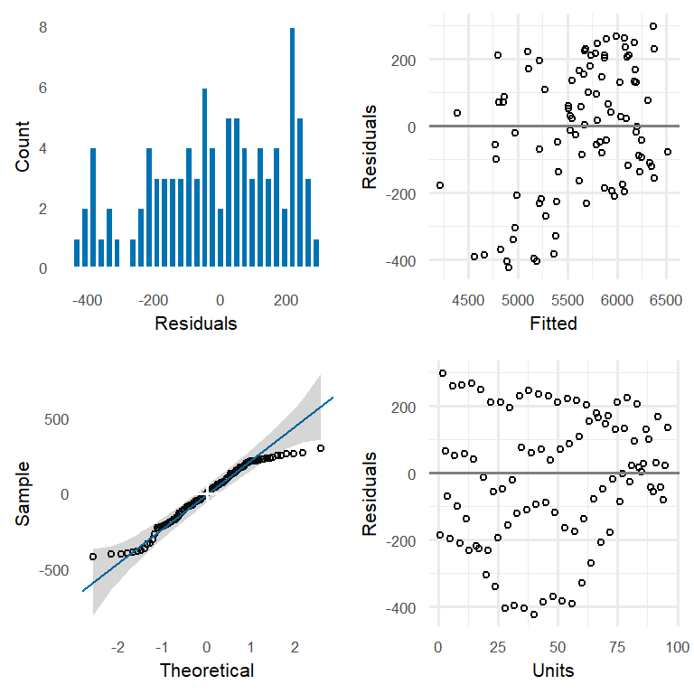

```r
plot(ta)
```

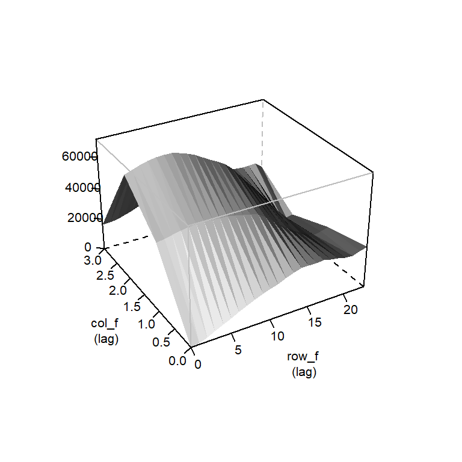

```r
plot(asreml::varioGram(ta))
```

### 2.0.6 Tensor Product P-Spline Model (TPS

```r
tps =  single_site_models(trial_2023, "tps", "resis:log_centered_initial")
tps = update.asreml(tps)
```

```r
wald(tps,  trace=FALSE)
```

```
Wald tests for fixed effects.
Response: yield_kg_ha
Terms added sequentially; adjusted for those above.

                           Df Sum of Sq Wald statistic Pr(Chisq)
(Intercept)                 1 474098748         7721.9 < 2.2e-16 ***
cult                        5   4481415           73.0 2.442e-14 ***
seed_trt                    1    155983            2.5 0.1109538
TP.CR.2                     1    307155            5.0 0.0253064 *
TP.CR.3                     1    895795           14.6 0.0001336 ***
TP.CR.4                     1    114361            1.9 0.1723186
cult:seed_trt               5    741972           12.1 0.0336430 *
resis:log_centered_initial  2   1321108           21.5 2.126e-05 ***
residual (MS)                     61397
---
Signif. codes:  0 '***' 0.001 '**' 0.01 '*' 0.05 '.' 0.1 ' ' 1
```

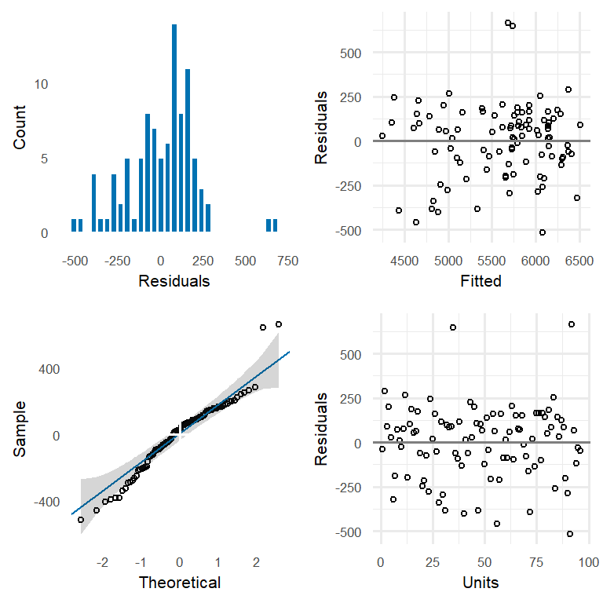

```r
plot(tps)
```

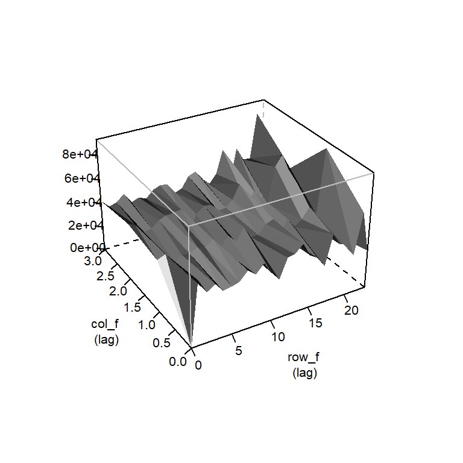

```r
plot(asreml::varioGram(tps))
```

## 2.1 Model Comparisons

| model | loglik | p | q | b | AIC | BIC | logdet |
| --- | --- | --- | --- | --- | --- | --- | --- |
| baseline | -615.7 | 12 | 2 | 1 | 1,259.4 | 1,295.3 | 118.6 |
| scn_covariate | -604.8 | 14 | 3 | 0 | 1,243.6 | 1,287.2 | 133.3 |
| ar1 | -599.5 | 14 | 3 | 1 | 1,233.0 | 1,276.6 | 131.2 |
| ar1_nugget | -592.4 | 14 | 3 | 2 | 1,218.8 | 1,262.4 | 130.1 |
| ta | -587.0 | 16 | 3 | 2 | 1,212.1 | 1,260.8 | 142.2 |
| tps | -586.0 | 17 | 6 | 2 | 1,217.9 | 1,276.9 | 168.7 |

## 2.2 Seed Treatment Effects

| Model | Contrast | Reference | predicted.value | standard.error | lower.Confidence.limit | upper.Confidence.limit |
| --- | --- | --- | --- | --- | --- | --- |
| baseline | Fluopyram vs Base | 5,582.0 | 68.4 | 71.3 | -73.6 | 210.3 |
| scn_covariate | Fluopyram vs Base | 5,597.3 | 50.1 | 63.5 | -77.9 | 178.0 |
| ar1 | Fluopyram vs Base | 5,592.6 | 66.9 | 50.8 | -35.2 | 169.0 |
| ar1_nugget | Fluopyram vs Base | 5,621.5 | 65.7 | 51.4 | -37.2 | 168.6 |
| ta | Fluopyram vs Base | 5,608.6 | 62.7 | 52.9 | -43.2 | 168.6 |
| tps | Fluopyram vs Base | 5,573.1 | 62.7 | 52.3 | -42.0 | 167.5 |

## 2.3 Cultivar and Interaction Comparisons

| Model | Contrast | Reference | predicted.value | standard.error | lower.Confidence.limit | upper.Confidence.limit |
| --- | --- | --- | --- | --- | --- | --- |
| baseline | Peking vs PI88788 | 5,424.3 | 383.9 | 71.4 | 241.7 | 526.1 |
| scn_covariate | Peking vs PI88788 | 5,415.1 | 414.6 | 77.1 | 257.4 | 571.9 |
| ar1 | Peking vs PI88788 | 5,436.7 | 378.8 | 80.6 | 218.0 | 539.6 |
| ar1_nugget | Peking vs PI88788 | 5,466.3 | 376.0 | 70.9 | 234.6 | 517.4 |
| ta | Peking vs PI88788 | 5,450.0 | 379.9 | 68.6 | 243.0 | 516.8 |
| tps | Peking vs PI88788 | 5,421.6 | 365.7 | 69.6 | 226.4 | 505.1 |
| baseline | Peking + Base vs PI88788 + Fluopyram | 5,455.9 | 315.5 | 102.6 | 111.3 | 519.7 |
| scn_covariate | Peking + Base vs PI88788 + Fluopyram | 5,430.0 | 364.6 | 102.6 | 157.6 | 571.5 |
| ar1 | Peking + Base vs PI88788 + Fluopyram | 5,460.2 | 311.9 | 98.0 | 115.3 | 508.5 |
| ar1_nugget | Peking + Base vs PI88788 + Fluopyram | 5,496.2 | 310.3 | 90.1 | 130.0 | 490.7 |
| ta | Peking + Base vs PI88788 + Fluopyram | 5,477.6 | 317.2 | 89.1 | 138.9 | 495.6 |
| tps | Peking + Base vs PI88788 + Fluopyram | 5,443.1 | 303.0 | 89.5 | 123.7 | 482.3 |

## 2.4 Variance Components

| Component | baseline | scn_covariate | ar1 | ar1_nugget | ta | tps |
| --- | --- | --- | --- | --- | --- | --- |
| block | 205469.0 (114417.1) | 134798.8 (77434.7) | 109761.6 (71264.1) | 0.11 (NA) | 0.02 (NA) | 0.10 (NA) |
| wp | 0.01 (NA) | 5890.1 (17120.9) | 0.01 (NA) | 0.02 (NA) | 0.05 (NA) | 0.10 (NA) |
| units!R | 120231.7 (19380.8) | NA | NA | NA | NA | NA |
| row_f:col_f!R | NA | 94402.3 (20883.7) | 115104.2 (24919.2) | 178042.1 (116217.4) | 67731.2 (45563.4) | 61396.7 (12709.9) |
| row_f:col_f!row_f!cor | NA | NA | 0.41 (0.12) | 0.95 (0.05) | 0.92 (0.08) | NA |
| units!units | NA | NA | NA | 55539.8 (13261.2) | 61306.9 (13900.2) | NA |
| grp(TP.R.1_fcol) | NA | NA | NA | NA | NA | 1765980.1 (1886014.9) |
| grp(TP.R.2_fcol) | NA | NA | NA | NA | NA | 902655.0 (1145284.0) |
| grp(TP.C.1_frow) | NA | NA | NA | NA | NA | 226653.3 (192752.0) |
| grp(TP.C.2_frow) | NA | NA | NA | NA | NA | 134322.3 (199737.6) |
| grp(TP_fcol_frow) | NA | NA | NA | NA | NA | 42250.2 (96347.4) |

## 2.5 Coeficient of Damage

| Model | Resistance | Estimate | StdError | PercentEffect |
| --- | --- | --- | --- | --- |
| scn_covariate | Peking_initial | -262.2 | 75.8 | -4.6 |
| scn_covariate | PI88788_initial | -325.7 | 75.7 | -5.7 |
| ar1 | Peking_initial | -249.8 | 75.9 | -4.4 |
| ar1 | PI88788_initial | -309.1 | 76.6 | -5.4 |
| ar1_nugget | Peking_initial | -257.6 | 72.1 | -4.5 |
| ar1_nugget | PI88788_initial | -288.2 | 70.0 | -5.0 |
| ta | Peking_initial | -319.0 | 71.7 | -5.5 |
| ta | PI88788_initial | -312.1 | 67.2 | -5.4 |
| tps | Peking_initial | -262.1 | 71.4 | -4.6 |
| tps | PI88788_initial | -293.1 | 69.8 | -5.1 |

# 3 Multi-site Analysis

We evaluated six multi-site linear mixed models to estimate the effects of cultivar resistance and fluopyram seed treatment on soybean yield under variable SCN pressure across two environments.

```r
# Check for rank deficiencies
model_matrix = model.matrix(~ site*seed_trt*cult, data = dat)
qr_mm = qr(model_matrix)
rank_deficiency = ncol(model_matrix) - qr_mm$rank;rank_deficiency # Should be 0 ideally
```

```
[1] 2
```

There is unbalance in the dataset.

### 3.0.1 Baseline Model

```r
baseline = multi_site_models(dat, "baseline")

baseline = update.asreml(baseline)
baseline = update.asreml(baseline)
```

```r
wald(baseline,  trace=FALSE)
```

```
Wald tests for fixed effects.
Response: yield_kg_ha
Terms added sequentially; adjusted for those above.

              Df Sum of Sq Wald statistic Pr(Chisq)
(Intercept)    1   2530.28        2530.28 < 2.2e-16 ***
site           1      6.70           6.70 0.0096577 **
cult           5     53.88          53.88 2.215e-10 ***
seed_trt       1     13.22          13.22 0.0002775 ***
cult:seed_trt  5      1.01           1.01 0.9619166
residual (MS)         1.00
---
Signif. codes:  0 '***' 0.001 '**' 0.01 '*' 0.05 '.' 0.1 ' ' 1
```

```r
structured = multi_site_models(dat, "structured")

structured = update.asreml(structured)
structured = update.asreml(structured)
```

```r
wald(structured,  trace=FALSE)
```

```
Wald tests for fixed effects.
Response: yield_kg_ha
Terms added sequentially; adjusted for those above.

              Df Sum of Sq Wald statistic Pr(Chisq)
(Intercept)    1   2530.28        2530.28 < 2.2e-16 ***
site           1      6.70           6.70 0.0096577 **
cult           5     53.88          53.88 2.215e-10 ***
seed_trt       1     13.22          13.22 0.0002775 ***
cult:seed_trt  5      1.01           1.01 0.9619166
residual (MS)         1.00
---
Signif. codes:  0 '***' 0.001 '**' 0.01 '*' 0.05 '.' 0.1 ' ' 1
```